# Week3

Thomas Rosenthal

28/01/2021

## Weekly Reflection

### My lesson in HTML node picking

For the past few weeks, I have been looking to programmatically navigate from a collections page (think: results from a search on a webstore) to a specific item’s page and extract details from it. To do this, a few things have to happen.

For this example, I will use the coffees from [The Library Speciality Coffee](https://www.thelibraryspecialtycoffee.com/) roaster on the [Eight Ounce Coffee](https://eightouncecoffee.ca/collections/the-library-specialty-coffee) website. Let’s suppose that we want to quickly grab the **Altitude** that each coffee was grown. We see that this information isn’t listed on the collection page.

[figure not shown]

We’ll need to navigate to each coffee’s page, extract the **Altitude**, write it to a table (assumedly with the coffee name, region, processing, etc as well), and then move on to the next coffee and repeat the process.

Our example coffee, Bensa Segera from Ethiopia, was grown at *2100-2300 m*:

[figure not shown]

Using [rvest](https://blog.rstudio.com/2014/11/24/rvest-easy-web-scraping-with-r/), we’ll aim to grab the desired information from a saved html file (because let’s be polite when we’re scraping someone else’s data). Depending on the site complexity, this might seem incredibly daunting, and you might find yourself doing a lot of trial and error to get to the information you want to extract…

```r
library(rvest)
```

```r
raw_data <- read_html("https://eightouncecoffee.ca/collections/the-library-specialty-coffee")
write_html(raw_data, "journal/Week3/inputs/TLS.html") # Note that we save the file as a html file
```

Once we have the html file, we’ll need to navigate to each coffee.

The page source will start to show us what we are looking for. Here I’ve searched for “Bensa” just to move through the page a bit quicker.

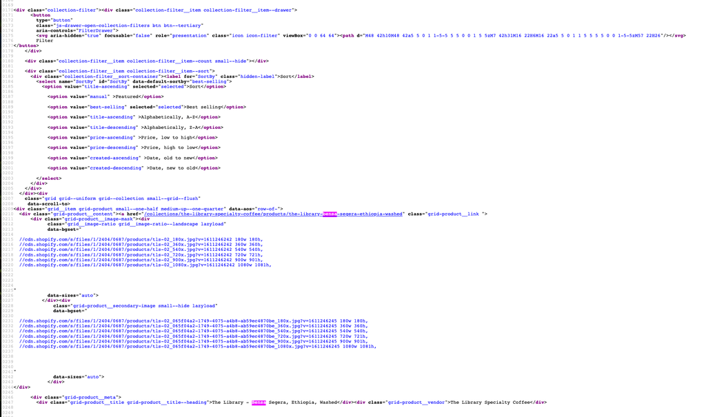

When I first started working with rvest, I thought it was necessary to traverse an entire html “tree” going from one node to another.

It was looking something like this:

```r
library(tidyverse)
rough <- raw_data %>%
  html_nodes("body") %>%
  html_nodes("div") %>%
  html_nodes("div") %>%
  html_nodes("main") %>%
  html_nodes("div") %>%
  html_nodes("div") %>%
  html_nodes("div") %>%
  html_text()
tibble(raw_text = head(rough[46:55],10))
```

```
## # A tibble: 10 x 1
##    raw_text
##    <chr>
##  1 "\n\n  \n      \n          \n            \n\n\n      \n        The Library -…
##  2 "\n  \n      \n          \n            \n\n\n      \n        The Library - B…
##  3 "\n      \n          \n            \n\n\n      \n        The Library - Bensa…
##  4 "\n          \n            \n"
##  5 "\n          "
##  6 "\n            "
##  7 "\n        The Library - Bensa Segera, Ethiopia, WashedThe Library Specialty…
##  8 "The Library - Bensa Segera, Ethiopia, Washed"
##  9 "The Library Specialty Coffee"
## 10 "\n       No reviews  \n"
```

On a side note, it was possible to just use html_nodes() once:

```
html_nodes("body div div main div div div") %>%
html_text()
```

…but this is a bit beside the point!

I have filtered this down to exclude a ton of irrelevant information for the sake of this writeup (like the first 45 rows for example), but this isn’t very programmatic. In reality, I ended up writing something to grab the coffee lines because they had a unique number of \n \n \n \n characters.

```r
library(data.table)
some_data <-
tibble(raw_text = rough[46:81])

some_data <- some_data %>%
  mutate(is_TLS = if_else(raw_text %like% "\n\n\n\n\n\n\n\n\n\n\n\n\n\n ",1,0)) %>%
  filter(is_TLS == 1) %>%
  select(-is_TLS)
some_data
```

```
## # A tibble: 12 x 1
##    raw_text
##    <chr>
##  1 "\n\n  \n      \n          \n            \n\n\n      \n        The Library -…
##  2 "\n  \n      \n          \n            \n\n\n      \n        The Library - B…
##  3 "\n      \n          \n            \n\n\n      \n        The Library - Bensa…
##  4 "\n        The Library - Bensa Segera, Ethiopia, WashedThe Library Specialty…
##  5 "\n  \n      \n          \n            \n\n\n      \n        The Library - L…
##  6 "\n      \n          \n            \n\n\n      \n        The Library - La Pa…
##  7 "\n        The Library - La Palma yi El Tucan lot416, Colombia, Anaerobic wa…
##  8 "\n  \n      \n          \n            \n\n\n      \n        The Library - S…
##  9 "\n      \n          \n            \n\n\n      \n        The Library - San P…
## 10 "\n        The Library - San Pedro Necta, Guatemala, WashedThe Library Speci…
## 11 "\n  \n      \n          \n            \n\n\n      \n        The Library - P…
## 12 "\n      \n          \n            \n\n\n      \n        The Library - Potos…
```

Obviously this wasn’t working well – I ended up with a lot of extra data cleaning, and the number of \n characters was changing week by week. Ouch.

Unfortunately, even figuring out that coffee names were appearing every n-th row wasn’t particularly programmatic…it would change week to week.

```r
tibble(raw_text = head(rough[c(53,64,75,86)],4))
```

```
## # A tibble: 4 x 1
##   raw_text
##   <chr>
## 1 The Library - Bensa Segera, Ethiopia, Washed
## 2 The Library - La Palma yi El Tucan lot416, Colombia, Anaerobic washed
## 3 The Library - San Pedro Necta, Guatemala, Washed
## 4 The Library - Potosi, Colombia, Washed
```

### Picking the right html_node()

A better solution requires that we go back to the page source.

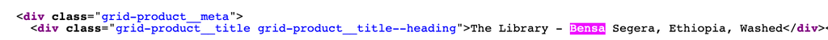

While I was trying to browse through these html files with 12,000 lines, I noticed that almost every `<div>` had either an **id =** or **class =** within it. Ah ha.

Let’s try that instead.

```r
clean <- raw_data %>%
  html_nodes("div [class='grid-product__title grid-product__title--heading']") %>%
  html_text()
clean
```

```
## [1] "The Library - Bensa Segera, Ethiopia, Washed"
## [2] "The Library - La Palma yi El Tucan lot416, Colombia, Anaerobic washed"
## [3] "The Library - San Pedro Necta, Guatemala, Washed"
## [4] "The Library - Potosi, Colombia, Washed"
```

This is great. Not only have we totally forgotten about this `<div> <div> <div> <main>` nonsense, we are navigating to a single place on the webpage.

This allows us to turn each of these coffee name strings into their respective URLs. I noticed early on that coffee names were always the same as the URLs (as lowercase strings with hyphens replacing spaces).

Let’s make it lowercase with `str_to_lower`:

```r
our_data <- tibble(raw_text = clean)

coffee_names <- our_data %>%
  mutate(lower_name =  str_to_lower(raw_text)) %>%
  select(lower_name)
coffee_names
```

```
## # A tibble: 4 x 1
##   lower_name
##   <chr>
## 1 the library - bensa segera, ethiopia, washed
## 2 the library - la palma yi el tucan lot416, colombia, anaerobic washed
## 3 the library - san pedro necta, guatemala, washed
## 4 the library - potosi, colombia, washed
```

Some substitutions will help us here:

```r
hypen_names <- coffee_names %>%
  apply( MARGIN = 2, FUN = trimws) %>%
  sapply(gsub, pattern = " ", replacement = "-", fixed = TRUE) %>%
  sapply(gsub, pattern = ",", replacement = "", fixed = TRUE) %>%
  sapply(gsub, pattern = "---", replacement = "-", fixed = TRUE) %>%
  as.data.frame() %>%
  rename(Hypen_Name = 1)

rownames(hypen_names) <- 1:nrow(hypen_names)
hypen_names
```

```
##                                                          Hypen_Name
## 1                          the-library-bensa-segera-ethiopia-washed
## 2 the-library-la-palma-yi-el-tucan-lot416-colombia-anaerobic-washed
## 3                      the-library-san-pedro-necta-guatemala-washed
## 4                                the-library-potosi-colombia-washed
```

Now we can just add the collection prefix with paste: ‘https://eightouncecoffee.ca/collections/the-library-specialty-coffee/products/’

```r
URLs <- paste0("https://eightouncecoffee.ca/collections/the-library-specialty-coffee/products/",hypen_names[,1])
URLs[1]
```

```
## [1] "https://eightouncecoffee.ca/collections/the-library-specialty-coffee/products/the-library-bensa-segera-ethiopia-washed"
```

Within a for-loop, we can easily feed this into another rvest `read_html`, pick the correct `html_node()` and extract the **Altitude**.

```r
coffee_table <- data.frame()

#I will just do this for the first coffee
for(i in URLs[1]){
  coffee_row <- read_html(i)

  coffee_details <-
  coffee_row %>%
    html_nodes("div [id='content'] ul li p") %>%
    html_text()

  #write it out so you can use it again!
  write_html(coffee_row,paste0("journal/Week3/inputs/coffee.html"))

  coffee <- tibble(raw_text = coffee_details)

  #seperate details row into relevent columns
  coffee <- coffee %>%
    pivot_wider(names_from = 1, values_from = raw_text) %>%
    rename(table = 1) %>%
    separate(table, into = c("1","Region","Variety","Processing","Altitude", "TastingNotes"), sep = "\\w+:",  remove = TRUE) %>%
    select("Region","Variety","Processing","Altitude", "TastingNotes")

#append to a table
  for (i in nrow(coffee)) {
      coffee_table <- rbind(coffee_table, data.frame(coffee))
  }
  #this is a nice little polite pause during loops!
  Sys.sleep(2.5)
}
coffee_table
```

```
##     Region    Variety Processing        Altitude
## 1  Sidamo   Heirloom     Washed   2100 - 2300 m
##                         TastingNotes
## 1  Yellow peach, Black berry, Floral
```

There we have it. Our **Altitude** is *2100-2300 m* just as we expected.

### Using html_attr() instead…

So it works. Great. But there’s a problem with this approach. It requires:

1. coffee names to be the same as their URLs (or at least to have some discernable pattern)
2. coffee names to be free of typos

That last point seemed like it wouldn’t happen. But I found out pretty quickly that I was wrong.

[figure not shown]

It might be hard to notice what’s happening here, but “Karogoto **AB**” should have been “Karogoto **AA**” (AA and AB are Kenyan grades, which isn’t overly important, but maybe you were wondering!)

We can write a function to remove URLs that are incorrect:

```
checkURLs <- lapply(URLs, function(u) {
  tryCatch({
    html_obj <- read_html(u)
    draft_table <- html_nodes(html_obj,'table')
    cik <- substr(u,start = 41,stop = 47)
    draft1 <- html_table(draft_table,fill = TRUE)
    final <- u
  }, error = function(x) NULL)
})
```

…but there’s a better solution entirely. Extract the URL specifically using `html_attr` rather than `html_text`.

While digging around in the page source, I noticed that the URL was already listed:

[figure not shown]

So immediately I tried to grab that with class = grid-product__link

```r
url <- raw_data %>%
  html_nodes("div [class='grid-product__content'] a [class='grid-product__link ']") %>%
  html_text()
url
```

```
## character(0)
```

No dice. This is where `html_attr` comes in.

```r
url <- raw_data %>%
  html_nodes("div [class='grid-product__content'] a") %>%
  html_attr("href")
url
```

```
## [1] "/collections/the-library-specialty-coffee/products/the-library-bensa-segera-ethiopia-washed"
## [2] "/collections/the-library-specialty-coffee/products/the-library-la-palma-yi-el-tucan-lot416-colombia-anaerobic-washed"
## [3] "/collections/the-library-specialty-coffee/products/the-library-san-pedro-necta-guatemala-washed"
## [4] "/collections/the-library-specialty-coffee/products/the-library-potosi-colombia-washed"
```

We’ve picked the right html_node with class=, and then asked for the href= and ended up with our URLs.

Our Kenyan AA ≠ Kenyan AB problem is no more. We’ve asked for the URL directly from the webpage, rather than extrapolating the name-to-URL pattern and replacing the spaces with hyphens.

Everything else is the same from here.